# 002_preprocessing_data

### Importo librerias

```python
import pandas as pd
import numpy as np
import seaborn as sns
from matplotlib import pyplot as plt
import plotly.express as px
from sklearn.impute import KNNImputer
import scipy.stats as ss
import warnings

pd.set_option('display.max_columns', 500)
pd.set_option('display.max_rows', 5000)
```

### Funciones

**Buenas prácticas**

Voy guardando las funciones que están automatizadas y pienso que me van a servir en otros proyectos en un funciones_auxiliares.py y lo importo:

```python
def plot_feature(df, col_name, isContinuous, target):
    """
    Visualize a variable with and without faceting on the loan status.
    - df dataframe
    - col_name is the variable name in the dataframe
    - full_name is the full variable name
    - continuous is True if the variable is continuous, False otherwise
    """
    f, (ax1, ax2) = plt.subplots(nrows=1, ncols=2, figsize=(12,3), dpi=90)

    count_null = df[col_name].isnull().sum()
    if isContinuous:

        sns.histplot(df.loc[df[col_name].notnull(), col_name], kde=False, ax=ax1)
    else:
        sns.countplot(df, x=col_name, color='#5975A4', saturation=1, ax=ax1)
    ax1.set_xlabel(col_name)
    ax1.set_ylabel('Count')
    ax1.set_title(col_name+ ' Numero de nulos: '+str(count_null))
    plt.xticks(rotation = 90)


    if isContinuous:
        sns.boxplot(x=col_name, y=target, data=df, ax=ax2)
        ax2.set_ylabel('')
        ax2.set_title(col_name + ' by '+target)
    else:
        data = df.groupby(col_name)[target].value_counts(normalize=True).to_frame('proportion').reset_index()
        data.columns = [i, target, 'proportion']
        #sns.barplot(x = col_name, y = 'proportion', hue= target, data = data, saturation=1, ax=ax2)
        sns.barplot(x = col_name, y = 'proportion', hue= target, data = data, saturation=1, ax=ax2)
        ax2.set_ylabel(target+' fraction')
        ax2.set_title(target)
        plt.xticks(rotation = 90)
    ax2.set_xlabel(col_name)

    plt.tight_layout()


def dame_variables_categoricas(dataset=None):
    '''
    ----------------------------------------------------------------------------------------------------------
    Función dame_variables_categoricas:
    ----------------------------------------------------------------------------------------------------------
        -Descripción: Función que recibe un dataset y devuelve una lista con los nombres de las
        variables categóricas
        -Inputs:
            -- dataset: Pandas dataframe que contiene los datos
        -Return:
            -- lista_variables_categoricas: lista con los nombres de las variables categóricas del
            dataset de entrada con menos de 100 valores diferentes
            -- 1: la ejecución es incorrecta
    '''
    if dataset is None:
        print(u'\nFaltan argumentos por pasar a la función')
        return 1
    lista_variables_categoricas = []
    other = []
    for i in dataset.columns:
        if (dataset[i].dtype!=float) & (dataset[i].dtype!=int):
            unicos = int(len(np.unique(dataset[i].dropna(axis=0, how='all'))))
            if unicos < 100:
                lista_variables_categoricas.append(i)
            else:
                other.append(i)

    return lista_variables_categoricas, other


def get_corr_matrix(dataset = None, metodo='pearson', size_figure=[10,8]):
    # Para obtener la correlación de Spearman, sólo cambiar el metodo por 'spearman'

    if dataset is None:
        print(u'\nHace falta pasar argumentos a la función')
        return 1
    sns.set(style="white")
    # Compute the correlation matrix
    corr = dataset.corr(method=metodo)
    # Set self-correlation to zero to avoid distraction
    for i in range(corr.shape[0]):
        corr.iloc[i, i] = 0
    # Set up the matplotlib figure
    f, ax = plt.subplots(figsize=size_figure)
    # Draw the heatmap with the mask and correct aspect ratio
    sns.heatmap(corr, center=0,
                square=True, linewidths=.5,  cmap ='viridis' ) #cbar_kws={"shrink": .5}
    plt.show()

    return 0

def get_deviation_of_mean_perc(pd_loan, list_var_continuous, target, multiplier):
    """
    Devuelve el porcentaje de valores que exceden del intervalo de confianza
    :type series:
    :param multiplier:
    :return:
    """
    pd_final = pd.DataFrame()

    for i in list_var_continuous:

        series_mean = pd_loan[i].mean()
        series_std = pd_loan[i].std()
        std_amp = multiplier * series_std
        left = series_mean - std_amp
        right = series_mean + std_amp
        size_s = pd_loan[i].size

        perc_goods = pd_loan[i][(pd_loan[i] >= left) & (pd_loan[i] <= right)].size/size_s
        perc_excess = pd_loan[i][(pd_loan[i] < left) | (pd_loan[i] > right)].size/size_s

        if perc_excess>0:
            pd_concat_percent = pd.DataFrame(pd_loan[target][(pd_loan[i] < left) | (pd_loan[i] > right)] \
                                             .value_counts(normalize=True).reset_index()).T
            pd_concat_percent.columns = [pd_concat_percent.iloc[0,0],
                                         pd_concat_percent.iloc[0,1]]
            pd_concat_percent = pd_concat_percent.drop('index',axis=0)
            pd_concat_percent['variable'] = i
            pd_concat_percent['sum_outlier_values'] = pd_loan[i][(pd_loan[i] < left) | (pd_loan[i] > right)].size
            pd_concat_percent['porcentaje_sum_null_values'] = perc_excess
            pd_final = pd.concat([pd_final, pd_concat_percent], axis=0).reset_index(drop=True)

    if pd_final.empty:
        print('No existen variables con valores nulos')

    return pd_final


def get_percent_null_values_target(pd_loan, list_var_continuous, target):

    pd_final = pd.DataFrame()
    for i in list_var_continuous:
        if pd_loan[i].isnull().sum()>0:
            pd_concat_percent = pd.DataFrame(pd_loan[target][pd_loan[i].isnull()] \
                                             .value_counts(normalize=True).reset_index()).T
            pd_concat_percent.columns = [pd_concat_percent.iloc[0,0],
                                         pd_concat_percent.iloc[0,1]]
            pd_concat_percent = pd_concat_percent.drop('index',axis=0)
            pd_concat_percent['variable'] = i
            pd_concat_percent['sum_null_values'] = pd_loan[i].isnull().sum()
            pd_concat_percent['porcentaje_sum_null_values'] = pd_loan[i].isnull().sum()/pd_loan.shape[0]
            pd_final = pd.concat([pd_final, pd_concat_percent], axis=0).reset_index(drop=True)

    if pd_final.empty:
        print('No existen variables con valores nulos')

    return pd_final



def cramers_v(confusion_matrix):
    """
    calculate Cramers V statistic for categorial-categorial association.
    uses correction from Bergsma and Wicher,
    Journal of the Korean Statistical Society 42 (2013): 323-328

    confusion_matrix: tabla creada con pd.crosstab()

    """
    chi2 = ss.chi2_contingency(confusion_matrix)[0]
    n = confusion_matrix.sum()
    phi2 = chi2 / n
    r, k = confusion_matrix.shape
    phi2corr = max(0, phi2 - ((k-1)*(r-1))/(n-1))
    rcorr = r - ((r-1)**2)/(n-1)
    kcorr = k - ((k-1)**2)/(n-1)
    return np.sqrt(phi2corr / min((kcorr-1), (rcorr-1)))
```

## Lectura de datos del preprocesado inicial

Lectura de los datos y cambio de tipos de variables

```python
df_fraud = pd.read_csv("../data/pd_data_initial_preprocessing.csv").drop('Unnamed: 0',axis=1)
df_fraud.shape
```

```
(1000000, 32)
```

```python
df_fraud.columns
```

```
Index(['intended_balcon_amount', 'prev_address_months_count',
       'bank_months_count', 'current_address_months_count',
       'session_length_in_minutes', 'fraud_bool', 'foreign_request',
       'phone_mobile_valid', 'has_other_cards', 'proposed_credit_limit',
       'device_os', 'source', 'housing_status', 'keep_alive_session',
       'device_distinct_emails_8w', 'device_fraud_count', 'phone_home_valid',
       'credit_risk_score', 'email_is_free', 'income', 'employment_status',
       'date_of_birth_distinct_emails_4w', 'bank_branch_count_8w',
       'velocity_4w', 'velocity_24h', 'velocity_6h', 'zip_count_4w',
       'payment_type', 'days_since_request', 'customer_age',
       'name_email_similarity', 'month'],
      dtype='object')
```

```python
list_var_cat, other = dame_variables_categoricas(dataset=df_fraud)
df_fraud[list_var_cat] = df_fraud[list_var_cat].astype("category")
list_var_continuous = list(df_fraud.select_dtypes('float').columns)
df_fraud[list_var_continuous] = df_fraud[list_var_continuous].astype(float)
df_fraud.dtypes
```

```
intended_balcon_amount               float64
prev_address_months_count            float64
bank_months_count                    float64
current_address_months_count         float64
session_length_in_minutes            float64
fraud_bool                          category
foreign_request                      float64
phone_mobile_valid                   float64
has_other_cards                      float64
proposed_credit_limit                float64
device_os                           category
source                              category
housing_status                      category
keep_alive_session                   float64
device_distinct_emails_8w            float64
device_fraud_count                   float64
phone_home_valid                     float64
credit_risk_score                    float64
email_is_free                        float64
income                               float64
employment_status                   category
date_of_birth_distinct_emails_4w     float64
bank_branch_count_8w                 float64
velocity_4w                          float64
velocity_24h                         float64
velocity_6h                          float64
zip_count_4w                         float64
payment_type                        category
days_since_request                   float64
customer_age                         float64
name_email_similarity                float64
month                                float64
dtype: object
```

Este código prepara el conjunto de datos de nuestro dataframe para el análisis exploratorio, asegurándonos de que las variables categóricas y las variables continuas estén en el formato correcto.

## Separación en train y test estratificado

```python
df_fraud_bool = df_fraud['fraud_bool'] \
    .value_counts(normalize=True) \
    .mul(100).rename('percent').reset_index()

df_fraud_bool_conteo = df_fraud['fraud_bool'].value_counts().reset_index()
df_fraud_bool_pc = pd.merge(df_fraud_bool, df_fraud_bool_conteo, on=['index'], how='inner')
df_fraud_bool_pc
fig = px.histogram(df_fraud_bool_pc, x="index", y=['percent'])
fig.update_xaxes(tickvals = [0, 1])
fig.show()
```

[output not shown]

```python
from sklearn.model_selection import train_test_split
X_df_fraud, X_df_fraud_test, y_df_fraud, y_df_fraud_test = train_test_split(df_fraud.drop('fraud_bool',axis=1),
                                                                        df_fraud['fraud_bool'],
                                                                        stratify=df_fraud['fraud_bool'],
                                                                        test_size=0.2)
df_fraud_train = pd.concat([X_df_fraud, y_df_fraud],axis=1)
df_fraud_test = pd.concat([X_df_fraud_test, y_df_fraud_test],axis=1)
```

Dividimos nuestro conjunto de datos en train y test, con una proporción del 80% y 20% respectivamente

```python
print('== Train\n', df_fraud_train['fraud_bool'].value_counts(normalize=True))
print('== Test\n', df_fraud_test['fraud_bool'].value_counts(normalize=True))
```

```
== Train
 0    0.988971
1    0.011029
Name: fraud_bool, dtype: float64
== Test
 0    0.98897
1    0.01103
Name: fraud_bool, dtype: float64
```

## Visualización descriptiva de los datos

Veo el número de valores nulos por filas y por columnas

```python
pd_series_null_columns = df_fraud_train.isnull().sum().sort_values(ascending=False)
pd_series_null_rows = df_fraud_train.isnull().sum(axis=1).sort_values(ascending=False)
print(pd_series_null_columns.shape, pd_series_null_rows.shape)

pd_null_columnas = pd.DataFrame(pd_series_null_columns, columns=['nulos_columnas'])
pd_null_filas = pd.DataFrame(pd_series_null_rows, columns=['nulos_filas'])
pd_null_filas['target'] = df_fraud['fraud_bool'].copy()
pd_null_columnas['porcentaje_columnas'] = pd_null_columnas['nulos_columnas']/df_fraud_train.shape[0]
pd_null_filas['porcentaje_filas']= pd_null_filas['nulos_filas']/df_fraud_train.shape[1]
```

```
(32,) (800000,)
```

Vemos el número de valores nulos por filas y por columnas

```python
pd_null_columnas
```

|  | nulos_columnas | porcentaje_columnas |
| --- | --- | --- |
| intended_balcon_amount | 594044 | 0.742555 |
| prev_address_months_count | 570243 | 0.712804 |
| bank_months_count | 203046 | 0.253808 |
| current_address_months_count | 3373 | 0.004216 |
| session_length_in_minutes | 1595 | 0.001994 |
| velocity_6h | 0 | 0.000000 |
| date_of_birth_distinct_emails_4w | 0 | 0.000000 |
| bank_branch_count_8w | 0 | 0.000000 |
| velocity_4w | 0 | 0.000000 |
| velocity_24h | 0 | 0.000000 |
| payment_type | 0 | 0.000000 |
| zip_count_4w | 0 | 0.000000 |
| income | 0 | 0.000000 |
| days_since_request | 0 | 0.000000 |
| customer_age | 0 | 0.000000 |
| name_email_similarity | 0 | 0.000000 |
| month | 0 | 0.000000 |
| employment_status | 0 | 0.000000 |
| credit_risk_score | 0 | 0.000000 |
| email_is_free | 0 | 0.000000 |
| phone_home_valid | 0 | 0.000000 |
| device_fraud_count | 0 | 0.000000 |
| device_distinct_emails_8w | 0 | 0.000000 |
| keep_alive_session | 0 | 0.000000 |
| housing_status | 0 | 0.000000 |
| source | 0 | 0.000000 |
| device_os | 0 | 0.000000 |
| proposed_credit_limit | 0 | 0.000000 |
| has_other_cards | 0 | 0.000000 |
| phone_mobile_valid | 0 | 0.000000 |
| foreign_request | 0 | 0.000000 |
| fraud_bool | 0 | 0.000000 |

```python
pd_null_filas.head()
```

|  | nulos_filas | target | porcentaje_filas |
| --- | --- | --- | --- |
| 223147 | 4 | 0 | 0.125 |
| 264365 | 4 | 0 | 0.125 |
| 939557 | 4 | 0 | 0.125 |
| 565851 | 4 | 0 | 0.125 |
| 741863 | 4 | 0 | 0.125 |

Distribución del resto de variables

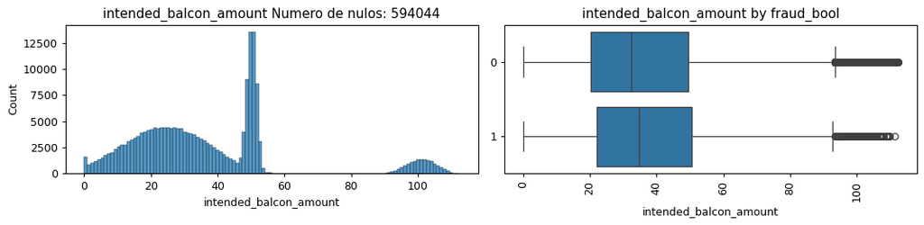

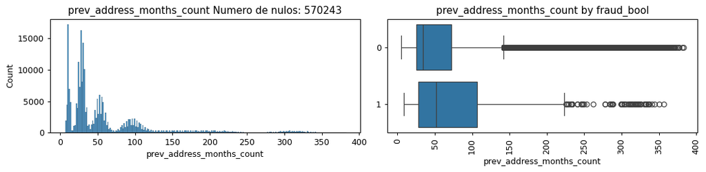

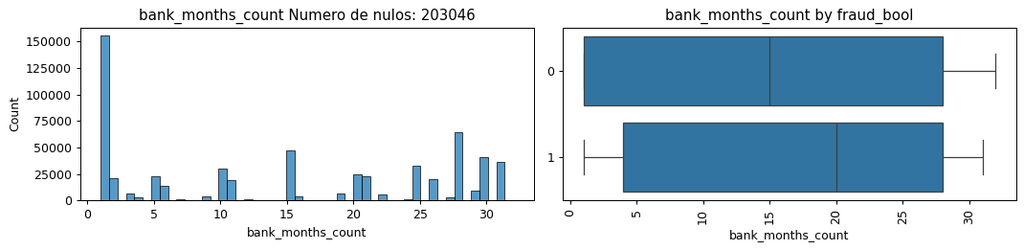

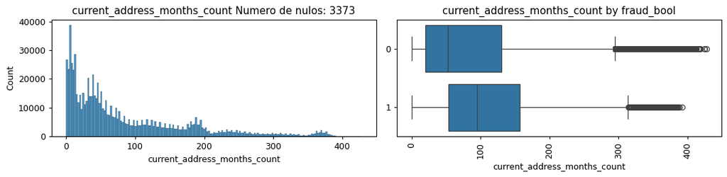

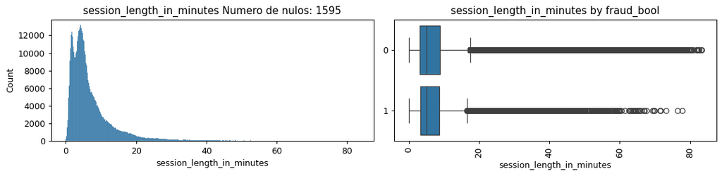

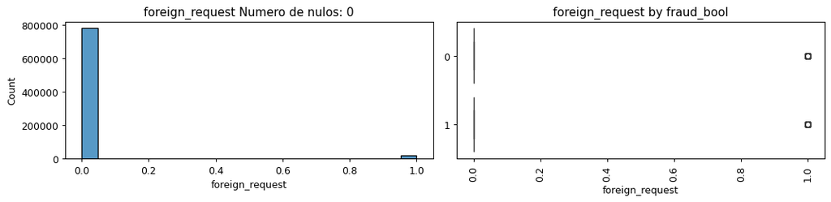

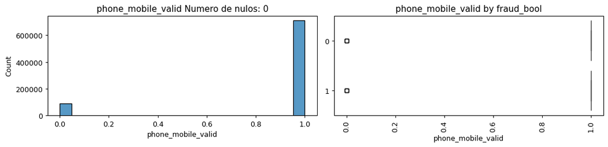

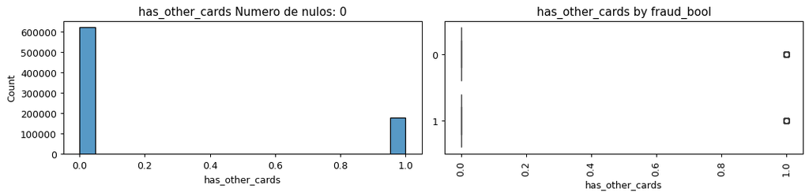

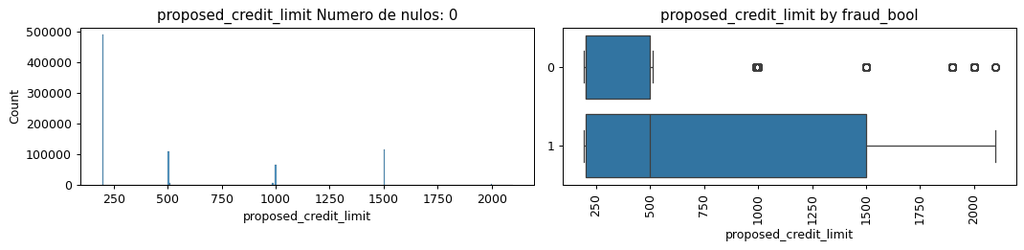

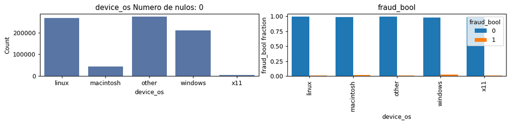

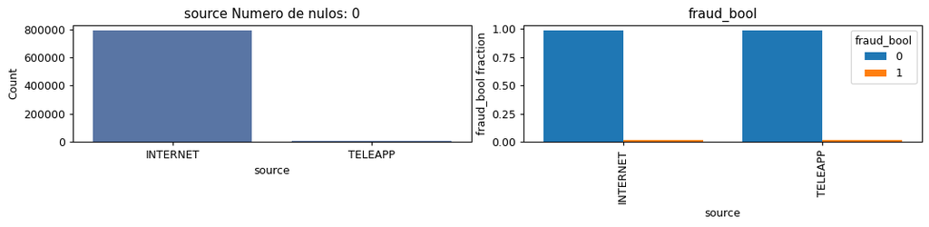

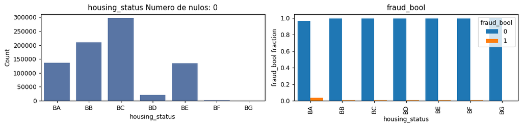

[19 more figures not shown]

```python
# warnings.filterwarnings('ignore')
for i in list(df_fraud_train.columns):
    if (df_fraud_train[i].dtype==float) & (i!='fraud_bool'):
        plot_feature(df_fraud_train, col_name=i, isContinuous=True, target='fraud_bool')
    elif  i!='fraud_bool':
        plot_feature(df_fraud_train, col_name=i, isContinuous=False, target='fraud_bool')
```

Se generan visualizaciones para las características del conjunto de datos, considerando si son de tipo float o categóricas, en relación con la variable objetivo 'fraud_bool'.

Por ejemplo, hay un gráfico de barras que compara la proporción de fraudes ('fraud_bool') en función del sistema operativo del dispositivo ('device_os'). Las barras representan el porcentaje de fraudes para cada sistema operativo, calculado sobre el total de observaciones en ese sistema. Se observa que las barras correspondientes al valor 0 son significativamente más altas en todos los sistemas operativos,indicando que la mayoría de las observaciones no son fraudes. Sin embargo, entre las barras del valor 1,las más altas se encuentran en los sistemas operativos 'Windows' y 'Macintosh', sugiriendo una posible asociaciónentre estos sistemas y un mayor porcentaje de fraudes.

Otro ejemplo es el gráfico de caja (boxplot) que compara la distribución del ingreso ('income') en función de la la proporción de fraudes ('fraud_bool'). Para las observaciones sin fraude, el boxplot muestra que la mayoría de los ingresos se encuentran entre 0.3 y 0.8, con una mediana en 0.6. Por otro lado, para las observaciones con fraude el rango de ingresos es más pequeño, y la mayoría de los valores se encuentran entre 0.6 y 0.9, situándose la median en 0.8. Se observa un outlier en 0.1. Este boxplot proporciona información sobre la variabilidad en los ingresos para las categorías de fraude y no fraude.

### Tratamiento de las variables continuas

A continuación, se tratan los valores missing, las correlaciones de las variables continuas y los outliers

```python
list_var_continuous
```

```
['intended_balcon_amount',
 'prev_address_months_count',
 'bank_months_count',
 'current_address_months_count',
 'session_length_in_minutes',
 'foreign_request',
 'phone_mobile_valid',
 'has_other_cards',
 'proposed_credit_limit',
 'keep_alive_session',
 'device_distinct_emails_8w',
 'device_fraud_count',
 'phone_home_valid',
 'credit_risk_score',
 'email_is_free',
 'income',
 'date_of_birth_distinct_emails_4w',
 'bank_branch_count_8w',
 'velocity_4w',
 'velocity_24h',
 'velocity_6h',
 'zip_count_4w',
 'days_since_request',
 'customer_age',
 'name_email_similarity',
 'month']
```

### Tratamiento de outliers

Los valores outlier se pueden sustituir por la media, mediana, valores extremos (media+3std o media-3std). Tras el siguiente análisis, he decidido como primera iteración dejarlos sin sustituir. Una vez llegue al modelo puedo realizar iteraciones utilizando diferentes métodos para comprobar si mejora el modelo

```python
get_deviation_of_mean_perc(df_fraud_train, list_var_continuous, target='fraud_bool', multiplier=3)
```

|  | 0.0 | 1.0 | variable | sum_outlier_values | porcentaje_sum_null_values |
| --- | --- | --- | --- | --- | --- |
| 0 | 0.989395 | 0.010605 | intended_balcon_amount | 1603 | 0.002004 |
| 1 | 0.992348 | 0.007652 | prev_address_months_count | 6926 | 0.008658 |
| 2 | 0.984093 | 0.015907 | current_address_months_count | 16974 | 0.021218 |
| 3 | 0.979897 | 0.020103 | session_length_in_minutes | 18853 | 0.023566 |
| 4 | 0.977867 | 0.022133 | foreign_request | 20196 | 0.025245 |
| 5 | 0.869132 | 0.130868 | proposed_credit_limit | 4921 | 0.006151 |
| 6 | 0.962266 | 0.037734 | device_distinct_emails_8w | 25547 | 0.031934 |
| 7 | 0.967905 | 0.032095 | credit_risk_score | 2773 | 0.003466 |
| 8 | 0.992558 | 0.007442 | date_of_birth_distinct_emails_4w | 4972 | 0.006215 |
| 9 | 0.989417 | 0.010583 | bank_branch_count_8w | 32789 | 0.040986 |
| 10 | 0.997788 | 0.002212 | velocity_24h | 452 | 0.000565 |
| 11 | 0.994228 | 0.005772 | velocity_6h | 3465 | 0.004331 |
| 12 | 0.990548 | 0.009452 | zip_count_4w | 13013 | 0.016266 |
| 13 | 0.988143 | 0.011857 | days_since_request | 14253 | 0.017816 |
| 14 | 0.957726 | 0.042274 | customer_age | 6316 | 0.007895 |

### Correlaciones

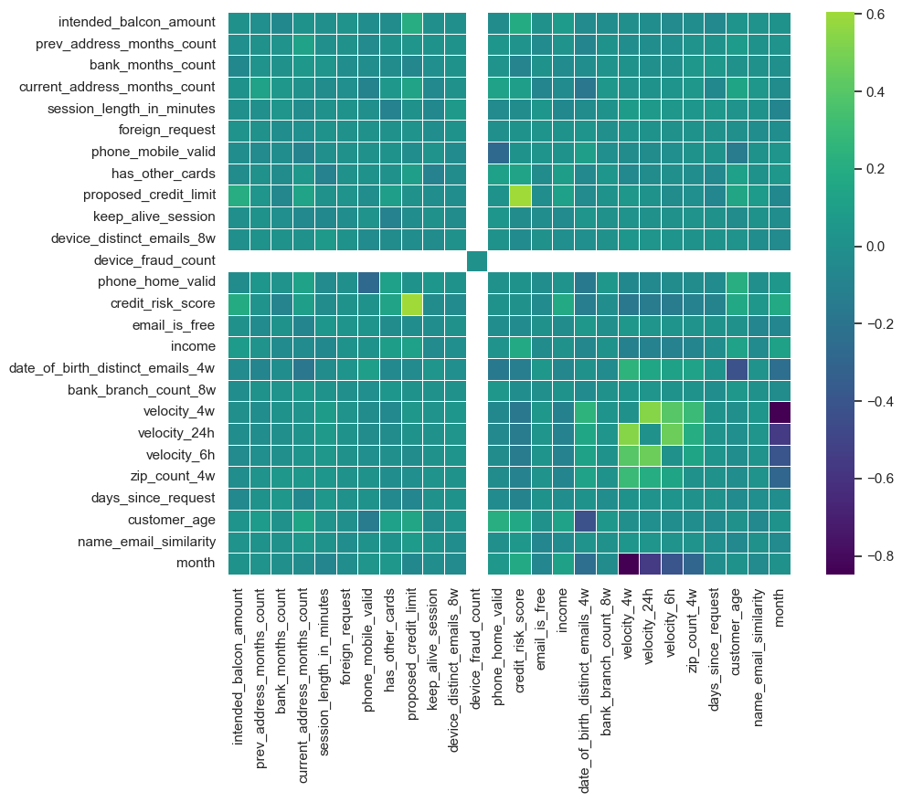

```
0
```

```python
get_corr_matrix(dataset = df_fraud_train[list_var_continuous],
                metodo='pearson', size_figure=[10,8])
```

```python
corr = df_fraud_train[list_var_continuous].corr('pearson')
new_corr = corr.abs()
new_corr.loc[:,:] = np.tril(new_corr, k=-1) # below main lower triangle of an array
new_corr = new_corr.stack().to_frame('correlation').reset_index().sort_values(by='correlation', ascending=False)
new_corr[new_corr['correlation']>0.6]
```

|  | level_0 | level_1 | correlation |
| --- | --- | --- | --- |
| 643 | month | velocity_4w | 0.848005 |
| 334 | credit_risk_score | proposed_credit_limit | 0.605937 |

El código identifica y muestra los pares de variables continuas que tienen una correlación absoluta mayor a 0.6, lo que podría indicar una relación más fuerte entre esas variables.

### Tratamiento de valores nulos

¿Son todos los nulos de una clase de la variable objetivo? o tienen el mismo porcentaje de la variable objetivo?

```python
list_var_continuous
```

```
['intended_balcon_amount',
 'prev_address_months_count',
 'bank_months_count',
 'current_address_months_count',
 'session_length_in_minutes',
 'foreign_request',
 'phone_mobile_valid',
 'has_other_cards',
 'proposed_credit_limit',
 'keep_alive_session',
 'device_distinct_emails_8w',
 'device_fraud_count',
 'phone_home_valid',
 'credit_risk_score',
 'email_is_free',
 'income',
 'date_of_birth_distinct_emails_4w',
 'bank_branch_count_8w',
 'velocity_4w',
 'velocity_24h',
 'velocity_6h',
 'zip_count_4w',
 'days_since_request',
 'customer_age',
 'name_email_similarity',
 'month']
```

```python
get_percent_null_values_target(df_fraud_train, list_var_continuous, target='fraud_bool')
```

|  | 0.0 | 1.0 | variable | sum_null_values | porcentaje_sum_null_values |
| --- | --- | --- | --- | --- | --- |
| 0 | 0.986878 | 0.013122 | intended_balcon_amount | 594044 | 0.742555 |
| 1 | 0.985776 | 0.014224 | prev_address_months_count | 570243 | 0.712804 |
| 2 | 0.983570 | 0.016430 | bank_months_count | 203046 | 0.253808 |
| 3 | 0.996442 | 0.003558 | current_address_months_count | 3373 | 0.004216 |
| 4 | 0.992476 | 0.007524 | session_length_in_minutes | 1595 | 0.001994 |

#### Opción 0:

Algunos algoritmos aceptan en su input valores missing

#### Opción 1:

Eliminar todas las filas que tengan valores nulos. En nuestro dataset no es lo más optimo debido a que hay bastantes filas que les ocurre esta situación

#### Opción 2:

Imputar los valores missing por:

media mediana maximo minimo valores extremos https://pandas.pydata.org/pandas-docs/stable/reference/api/pandas.DataFrame.fillna.html

Decido rellenar todas las columnas continuas menos session_length_in_minutes por el valor -99. De esta manera, diferencio los outlier del resto de la muestra poninendo un valor muy separado del resto de la variable. Se puede explorar el resultado del modelo utilizando diferentes métodos

```python
list_vars = list(set(list_var_continuous)-set(['session_length_in_minutes']))
df_fraud_train[list_vars] = df_fraud_train[list_vars].fillna(-99)
df_fraud_test[list_vars] = df_fraud_test[list_vars].fillna(-99)
```

```python
list_vars
```

```
['customer_age',
 'name_email_similarity',
 'device_distinct_emails_8w',
 'velocity_24h',
 'velocity_4w',
 'bank_months_count',
 'zip_count_4w',
 'credit_risk_score',
 'income',
 'email_is_free',
 'phone_mobile_valid',
 'bank_branch_count_8w',
 'phone_home_valid',
 'intended_balcon_amount',
 'current_address_months_count',
 'device_fraud_count',
 'date_of_birth_distinct_emails_4w',
 'proposed_credit_limit',
 'days_since_request',
 'foreign_request',
 'month',
 'keep_alive_session',
 'has_other_cards',
 'prev_address_months_count',
 'velocity_6h']
```

```python
df_fraud_test['session_length_in_minutes'].isnull().sum()
```

```
420
```

```python
get_percent_null_values_target(df_fraud_test, list_var_continuous, target='fraud_bool')
```

|  | 0.0 | 1.0 | variable | sum_null_values | porcentaje_sum_null_values |
| --- | --- | --- | --- | --- | --- |
| 0 | 0.985714 | 0.014286 | session_length_in_minutes | 420 | 0.0021 |

#### Opción 3:

```python
X_train = df_fraud_train[list(set(list_var_continuous))]
X_test = df_fraud_test[list(set(list_var_continuous))]
imputer = KNNImputer(n_neighbors=2, weights="uniform")
model = imputer.fit(X_train)
pd_input_train = pd.DataFrame(model.transform(X_train),
                              columns=[i+'_input' for i in list(set(list_var_continuous))],index=df_fraud_train.index)
pd_input_test = pd.DataFrame(model.transform(X_test),
                             columns=[i+'_input' for i in list(set(list_var_continuous))],index=df_fraud_test.index)

df_fraud_input_train = pd.concat([df_fraud_train, pd_input_train],axis=1).drop(list(set(list_var_continuous)),axis=1)
df_fraud_input_test = pd.concat([df_fraud_test, pd_input_test],axis=1).drop(list(set(list_var_continuous)),axis=1)
```

El código utiliza KNN para imputar los valores faltantes en las variables continuas del conjunto de datos, creando nuevos conjuntos de datos (df_fraud_input_train y df_fraud_input_test) con los valores imputados.

```python
df_fraud_input_train.shape
```

```
(800000, 32)
```

```python
get_percent_null_values_target(df_fraud_input_train, [i+'_input' for i in list_var_continuous], target='fraud_bool')
```

```
No existen variables con valores nulos
```

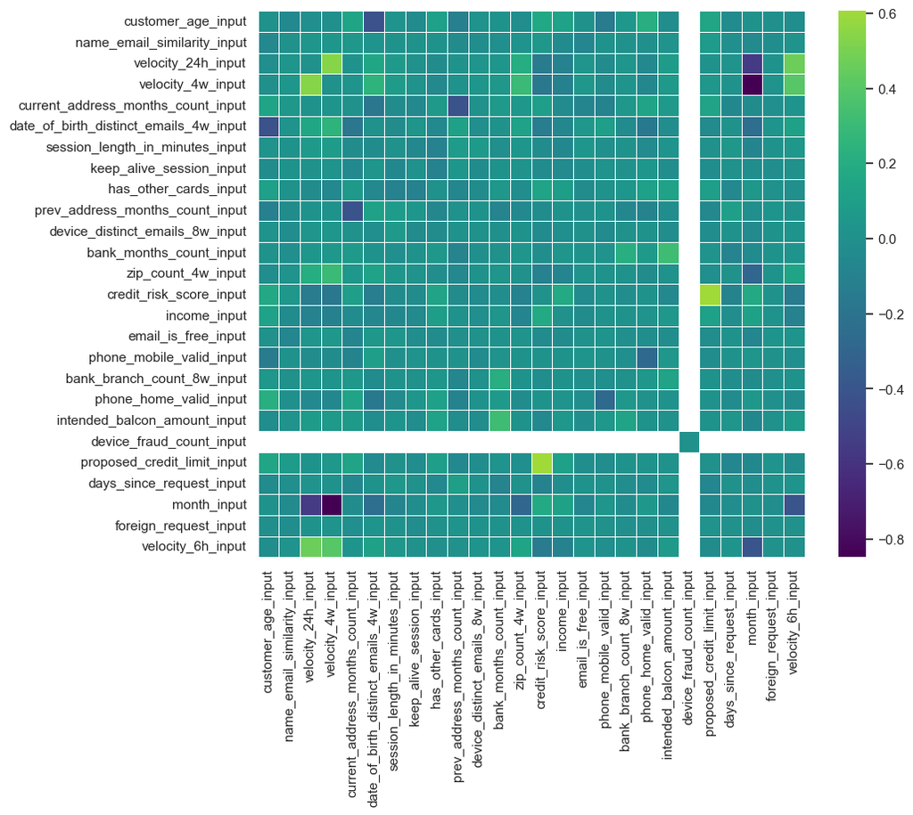

```
0
```

```python
list_var_continuous = list(df_fraud_input_train.select_dtypes('float').columns)
get_corr_matrix(dataset = df_fraud_input_train[list_var_continuous],
                metodo='pearson', size_figure=[10,8])
```

Este código selecciona las variables continuas imputadas en el train, y genera una matriz de correlación para explorar las relaciones lineales entre estas varibales, como realizamos en uno de los pasos anteriores.

```python
df_fraud_input_train.columns
```

```
Index(['device_os', 'source', 'housing_status', 'employment_status',
       'payment_type', 'fraud_bool', 'customer_age_input',
       'name_email_similarity_input', 'velocity_24h_input',
       'velocity_4w_input', 'current_address_months_count_input',
       'date_of_birth_distinct_emails_4w_input',
       'session_length_in_minutes_input', 'keep_alive_session_input',
       'has_other_cards_input', 'prev_address_months_count_input',
       'device_distinct_emails_8w_input', 'bank_months_count_input',
       'zip_count_4w_input', 'credit_risk_score_input', 'income_input',
       'email_is_free_input', 'phone_mobile_valid_input',
       'bank_branch_count_8w_input', 'phone_home_valid_input',
       'intended_balcon_amount_input', 'device_fraud_count_input',
       'proposed_credit_limit_input', 'days_since_request_input',
       'month_input', 'foreign_request_input', 'velocity_6h_input'],
      dtype='object')
```

### Tratamiento de las variables categoricas

Para la correlacion de spearman es necesario convertir las variables categoricas en numericas y luego obtener la correlación

También está el coeficiente V-Cramer https://stackoverflow.com/questions/46498455/categorical-features-correlation

```python
list_var_cat
```

```
['fraud_bool',
 'device_os',
 'source',
 'housing_status',
 'employment_status',
 'payment_type']
```

```python
confusion_matrix = pd.crosstab(df_fraud_input_train["fraud_bool"], df_fraud_input_train["device_os"])
print(confusion_matrix)
cramers_v(confusion_matrix.values)
```

```
device_os    linux  macintosh   other  windows   x11
fraud_bool
0           264767      42464  272474   205809  5663
1             1366        596    1589     5206    66
```

```
0.08034146008766434
```

Este código nos devuelve la matriz de confusión y el valor del coeficiente Cramér's V, que indica la fuerza de la asociación entre las variables categóricas "fraud_bool" y "device_os". Un valor cercano a 0 sugiere una asociación débil, mientras que un valor cercano a 1 indica una asociación más fuerte.

```python
confusion_matrix = pd.crosstab(df_fraud_input_train["fraud_bool"], df_fraud_input_train["fraud_bool"])
cramers_v(confusion_matrix.values)
```

```
0.9999426978916621
```

En este paso, estamos comparando 'fraud_bool' consigo misma, por lo que el valor que nos da es 1 aproximado, ya qye es una asociación perfecta, auqnue no es muy informativa.

```python
confusion_matrix = pd.crosstab(df_fraud_input_train["fraud_bool"], df_fraud_input_train["source"])
cramers_v(confusion_matrix.values)
```

```
0.003451873010446372
```

En este código comparamos 'fraud_bool' con la variable 'source'

### Tratamiento de valores nulos

En las variables categoricas, los valores nulos se suelen sustituir por una nueva clase: "sin valor" o por la moda

```python
df_fraud_input_train[list_var_cat] = df_fraud_input_train[list_var_cat].astype("object").fillna("SIN VALOR").astype("category")
df_fraud_input_test[list_var_cat] = df_fraud_input_test[list_var_cat].astype("object").fillna("SIN VALOR").astype("category")
```

## Guardado de la tabla

```python
df_fraud_input_train.to_csv("../data/train_pd_data_preprocessing_missing_outlier.csv")
df_fraud_input_test.to_csv("../data/test_pd_data_preprocessing_missing_outlier.csv")
```